# A Python Tour

**Dr. José Manuel MAGALLANES**  
Researcher at Center for Social Complexity, George Mason University (jmagalla@gmu.edu)  
Professor at Department of Social Sciences, Pontificia Universidad Catolica del Peru (jmagallanes@pucp.edu)

I will present some tools that Python has to organise data that is on the web. Python is very efficient for web scrapping, particularly making use of pair of libraries, which I will call first:

```python
from bs4 import BeautifulSoup as BS
import urllib2
```

The first step to get the data is to give the **[link](http://en.wikipedia.org/wiki/List_of_border_wars)** where the data is:

```python
#URL
WhereInWWW='http://en.wikipedia.org/wiki/List_of_border_wars'
```

From here, we need to get the html from that url:

```python
# get HTML
identification = { 'User-Agent' : 'Mozilla/4.0 (compatible; MSIE 5.5; Windows NT)'}
requestToServer = urllib2.Request(WhereInWWW,headers=identification)
responseFromServerInHTML = urllib2.urlopen(requestToServer)
```

I have made a *request* to the server, giving my **identification** (so that the probability that I get served *improves*), and when I get a *response*, I use it in *BS* (beautiful soup) like this:

```python
#now BS wil be in charge!
soup = BS(responseFromServerInHTML,'lxml')  #lxml is not the default parser. Wanna omitting it?.
# print  (soup.prettify()) # uncomment to see the WHOLE result.
```

Let's see what we have so far:

```python
### getting title, first try
print soup.find_all('h1') #there should be one HEADER level 1, right?
```

```
[<h1 class="firstHeading" id="firstHeading" lang="en"><span dir="auto">List of border conflicts</span></h1>]
```

I got the html in a bracket!...so it is a list with one element:

```python
### getting title, second try (going into the "span" tag)
print soup.find_all('h1')[0].span  #notice I use the index 0 to acces the first element of the list!
```

```
<span dir="auto">List of border conflicts</span>
```

```python
### getting title, third try
print soup.find_all('h1')[0].span.string #the text in the tag "span"
```

```
List of border conflicts
```

```python
### getting title, altenative to third try
print soup.find_all('h1')[0].span.get_text()
```

```
List of border conflicts
```

**KEEP IN MIND** that they **string** and **get_text()** do not always give you the same result (see details [here](http://omz-software.com/pythonista/docs/ios/beautifulsoup_ref.html)):

```python
someHtml = "<title>Normal text and <b>text in bold<b></title>"
soup = BS(someHtml)
```

```python
print soup.get_text()
```

```
Normal text and text in bold
```

```python
print soup.string
```

```
None
```

Different from the R [example](http://rpubs.com/jmagallanes/dataGathering) wher we just got a table, we are navigating the whole html of the wikipage. This flexibility will allow us to do interesting things. But let's continue getting familiar with BS:

```python
# get HTML
identification = { 'User-Agent' : 'Mozilla/4.0 (compatible; MSIE 5.5; Windows NT)'}
requestToServer = urllib2.Request(WhereInWWW,headers=identification)
responseFromServerInHTML = urllib2.urlopen(requestToServer)
soup = BS(responseFromServerInHTML,'lxml')

#subtitles try 1
for item in soup.find_all('h2'):
    print item.span
```

```
None
<span class="mw-headline" id="19th_Century">19th Century</span>
<span class="mw-headline" id="20th_Century_before_World_War_II">20th Century before World War II</span>
<span class="mw-headline" id="1945-2000">1945-2000</span>
<span class="mw-headline" id="21st_Century">21st Century</span>
<span class="mw-headline" id="See_also">See also</span>
<span class="mw-headline" id="References">References</span>
None
```

```python
###subtitles try 2
for subtitle in soup.find_all('h2'):
    print subtitle.span.string
```

```
---------------------------------------------------------------------------
AttributeError                            Traceback (most recent call last)
<ipython-input-13-7b7fdeb5bebc> in <module>()
      1 ###subtitles try 2
      2 for subtitle in soup.find_all('h2'):
----> 3     print subtitle.span.string

AttributeError: 'NoneType' object has no attribute 'string'
```

Why did I get this error? (*see above for the answer!*)

```python
###subtitles try 3
for subtitle in soup.find_all('h2'):
    try:
        print subtitle.span.string
    except AttributeError:
        print "no span tag in this subtitle!"
```

```
no span tag in this subtitle!
19th Century
20th Century before World War II
1945-2000
21st Century
See also
References
no span tag in this subtitle!
```

We see that there were a couple of subtitles that have no **span** tag.

```python
###alternative to try 4
for subtitle in soup.find_all('h2'):
    try:
        print subtitle.span.string
    except AttributeError:
        continue # cleaner results but lose information of who lacked the span tag!
```

```
19th Century
20th Century before World War II
1945-2000
21st Century
See also
References
```

It is time to get the tables, as we did in the R [example](http://rpubs.com/jmagallanes/dataGathering):

```python
allTables = soup.findAll('table', {'class': 'sortable wikitable'})#explore the page source to check tag and attribute!
```

```python
##see contents try 1
for eachTable in allTables:
    allRows=eachTable.find_all("tr")
    for eachRow in allRows:
        print eachRow.get_text()
```

```
Start
Finish
Conflict
Combatants
Fatalities


1846
1848
Mexican–American War
 United States -  Mexico
~29,000


1879
1883
War of the Pacific
 Chile -  Bolivia &  Peru
13,000+


Start
Finish
Conflict
Combatants
Fatalities


1910
1918
Border War
 United States -  Mexico
100+


1932
1935
Chaco War
 Bolivia -  Paraguay
~100,000
```

[output cut: 202 more lines]

```
42


2012
2012
2012 South Sudan–Sudan border conflict
 Sudan –  South Sudan
262-322


2012
Ongoing
2012 Syrian–Turkish border clashes
 Turkey -  Syria
20
```

In fact, you can see the contents of the table, but the column titles appear again and again, something I don't need.

```python
##see contents try 2
for eachTable in allTables:
        allRows=eachTable.find_all("tr")   # tr stands for table rows
        for eachRow in range(1,len(allRows)): #when I visit a table, I jump the first row
            allCells = allRows[eachRow].find_all("td") # td stands for table data, organized in cells.
            start=allCells[0].get_text(),
            end=allCells[1].get_text(),
            name=allCells[2].get_text(),
            countries=allCells[3].get_text(),
            fatalities=allCells[4].get_text()
            print start,end,name,countries,fatalities
```

```
(u'1846',) (u'1848',) (u'Mexican\u2013American War',) (u'\xa0United States - \xa0Mexico',) ~29,000
(u'1879',) (u'1883',) (u'War of the Pacific',) (u'\xa0Chile - \xa0Bolivia & \xa0Peru',) 13,000+
(u'1910',) (u'1918',) (u'Border War',) (u'\xa0United States - \xa0Mexico',) 100+
(u'1932',) (u'1935',) (u'Chaco War',) (u'\xa0Bolivia - \xa0Paraguay',) ~100,000
(u'1938',) (u'1938',) (u'Battle of Lake Khasan',) (u'\xa0Soviet Union \u2013 \xa0Japan',) ~1,300
(u'1939',) (u'1939',) (u'Slovak\u2013Hungarian War',) (u'\xa0Slovakia \u2013 \xa0Hungary',) 66
(u'1939',) (u'1939',) (u'Battle of Khalkhin Gol',) (u'\xa0Soviet Union and \xa0Mongolia \u2013 \xa0Japan and \xa0Manchukuo',) ~16,000
(u'1947',) (u'1948',) (u'Indo-Pakistani War of 1947',) (u'\xa0Pakistan \u2013 \xa0India',) ~3,000
(u'1950',) (u'Present (CF signed in 1953)',) (u'Korean War',) (u'\xa0South Korea - \xa0North Korea',) 2 419 010+
(u'1962',) (u'1962',) (u'Sino-Indian War',) (u'\xa0PRC \u2013 \xa0India',) ~4,000
(u'1965',) (u'1965',) (u'Indo-Pakistani War of 1965',) (u'\xa0Pakistan \u2013 \xa0India',) ~6,800
(u'1966',) (u'1989',) (u'South African Border War',) (u'\xa0Angola \u2013 \xa0South Africa',) Unknown
(u'1967',) (u'1967',) (u'Chola incident',) (u"\xa0India \u2013 \xa0People's Republic of China",) ~5
(u'1969',) (u'1969',) (u'Sino-Soviet border conflict',) (u'\xa0PRC \u2013 \xa0Soviet Union',) Unknown
(u'1971',) (u'1971',) (u'Indo-Pakistani War of 1971',) (u'\xa0Pakistan \u2013 \xa0India',) ~4,000+
(u'1979',) (u'1990',) (u'Sino-Vietnamese conflicts 1979-1990',) (u'\xa0Vietnam \u2013 \xa0China',) Unclear
(u'1980',) (u'1988',) (u'Iran\u2013Iraq War',) (u'\xa0Iran \u2013 \xa0Iraq',) 1-2 million[1]
(u'1981',) (u'1981',) (u'Paquisha War',) (u'\xa0Ecuador \u2013 \xa0Peru',) ~10
(u'1982',) (u'1982',) (u'1982 Ethiopian\u2013Somali Border War',) (u'\xa0Ethiopia \u2013 \xa0Somalia',) Unknown
(u'1984',) (u'1987',) (u'Siachen Conflict',) (u'\xa0Pakistan \u2013 \xa0India',) ~2,400.
(u'1985',) (u'1985',) (u'Agacher Strip War',) (u'\xa0Burkina Faso \u2013 \xa0Mali',) 179
(u'1987',) (u'1987',) (u'1987 Sino-Indian skirmish',) (u"\xa0India \u2013 \xa0People's Republic of China",) Unknown
(u'1987',) (u'1988',) (u'Thai\u2013Laotian Border War',) (u'\xa0Thailand \u2013 \xa0Laos',) ~1,000
(u'1989',) (u'1991',) (u'Mauritania\u2013Senegal Border War',) (u'\xa0Mauritania \u2013 \xa0Senegal',) Unknown
(u'1995',) (u'1995',) (u'Cenepa War',) (u'\xa0Ecuador \u2013 \xa0Peru',) ~450
(u'1998',) (u'2000',) (u'Eritrean-Ethiopian War',) (u'\xa0Ethiopia \u2013 \xa0Eritrea',) ~70,000
(u'1999',) (u'1999',) (u'Kargil War',) (u'\xa0India \u2013 \xa0Pakistan',) ~4,500
(u'2000',) (u'2006',) (u'2000-2006 Shebaa Farms conflict',) (u'\xa0Israel \u2013 \xa0Lebanon',) 30
(u'2001',) (u'2001',) (u'2001 Indian\u2013Bangladeshi border conflict',) (u'\xa0India \u2013 \xa0Bangladesh',) 20
(u'2008',) (u'2008',) (u'2008 Djiboutian\u2013Eritrean border conflict',) (u'\xa0Djibouti \u2013 \xa0Eritrea',) 144
(u'2008',) (u'2012',) (u'Cambodian\u2013Thai border dispute',) (u'\xa0Cambodia \u2013 \xa0Thailand',) 42
(u'2012',) (u'2012',) (u'2012 South Sudan\u2013Sudan border conflict',) (u'\xa0Sudan \u2013 \xa0South Sudan',) 262-322
(u'2012',) (u'Ongoing',) (u'2012 Syrian\u2013Turkish border clashes',) (u'\xa0Turkey - \xa0Syria',) 20
```

```python
##see contents alternative
print 'START','END','NAME','\t\t\t\t\t\tFATALITIES'
for eachTable in allTables:
        allRows=eachTable.find_all("tr")

        for eachRow in range(1,len(allRows)):
            allCells = allRows[eachRow].find_all("td")
            print allCells[0].string,
            print allCells[1].string,
            print allCells[2].string,
            print [country.string for country in allCells[3].find_all('a')],
            print allCells[4].string
```

```
START END NAME 						FATALITIES
1846 1848 Mexican–American War [u'United States', u'Mexico'] ~29,000
1879 1883 War of the Pacific [u'Chile', u'Bolivia', u'Peru'] 13,000+
1910 1918 Border War [u'United States', u'Mexico'] 100+
1932 1935 Chaco War [u'Bolivia', u'Paraguay'] ~100,000
1938 1938 Battle of Lake Khasan [u'Soviet Union', u'Japan'] ~1,300
1939 1939 Slovak–Hungarian War [u'Slovakia', u'Hungary'] 66
1939 1939 Battle of Khalkhin Gol [u'Soviet Union', u'Mongolia', u'Japan', u'Manchukuo'] ~16,000
1947 1948 Indo-Pakistani War of 1947 [u'Pakistan', u'India'] ~3,000
1950 Present (CF signed in 1953) Korean War [u'South Korea', u'North Korea'] 2 419 010+
1962 1962 Sino-Indian War [u'PRC', u'India'] ~4,000
1965 1965 Indo-Pakistani War of 1965 [u'Pakistan', u'India'] ~6,800
1966 1989 South African Border War [u'Angola', u'South Africa'] Unknown
1967 1967 Chola incident [u'India', u"People's Republic of China"] ~5
1969 1969 Sino-Soviet border conflict [u'PRC', u'Soviet Union'] Unknown
```

[output cut: 19 more lines]

As we are dealing with this one page to do the exercise, it would be better to save it locally:

```python
import os

# set working directory:
os.chdir("/Users/josemagallanes/Documents/GITHUBrepositories/Tutorials/TemplatesPython")  #customize this please!

WhereInWWW='http://en.wikipedia.org/wiki/List_of_border_wars'
identification = { 'User-Agent' : 'Mozilla/4.0 (compatible; MSIE 5.5; Windows NT)'}
requestToServer = urllib2.Request(WhereInWWW,headers=identification)
responseFromServerInHTML = urllib2.urlopen(requestToServer)

data = responseFromServerInHTML.read()
saveHtml  = open('warsList.html','w')
saveHtml.write(data)
saveHtml.close()
```

from now on, I will stop bothering wikipedia:

```python
openHtml = open("warsList.html","r")  #using data stored in my computer
soup = BS(openHtml,'lxml')
openHtml.close()

allTables = soup.findAll('table', {'class': 'sortable wikitable'})
##see contents try 2
for eachTable in allTables:
        allRows=eachTable.find_all("tr")   # tr stands for table rows
        for eachRow in range(1,len(allRows)): #when I visit a table, I jump the first row
            allCells = allRows[eachRow].find_all("td") # td stands for table data, organized in cells.
            start=allCells[0].get_text(),
            end=allCells[1].get_text(),
            name=allCells[2].get_text(),
            countries=[country.string for country in allCells[3].find_all('a')]
            fatalities=allCells[4].get_text()
```

We could save the output to a file, but we are interested in something different than we did in R. This time I want to use the fact that I am inside an html file that also has links to **other pages**. In particular, you can that see in the wikipedia page that the countries have links to their own wikipage. I want to get each of them :

```python
allTables = soup.findAll('table', {'class': 'sortable wikitable'})
for eachTable in allTables:
        allRows=eachTable.find_all("tr")   # tr stands for table rows
        for eachRow in range(1,len(allRows)): #when I visit a table, I jump the first row
            allCells = allRows[eachRow].find_all("td") # td stands for table data, organized in cells.
            start=allCells[0].get_text()
            end=allCells[1].get_text()
            name=allCells[2].get_text()
            fatalities=allCells[4].get_text()
            countries=[country.get_text() for country in allCells[3].find_all('a')]

            ##start - code added
            linksEachCountry=['http://en.wikipedia.org'+country.get('href') for country in allCells[3].find_all('a')]
            print linksEachCountry
            ##end  - code added
```

```
['http://en.wikipedia.org/wiki/United_States', 'http://en.wikipedia.org/wiki/Mexico']
['http://en.wikipedia.org/wiki/Chile', 'http://en.wikipedia.org/wiki/Bolivia', 'http://en.wikipedia.org/wiki/Peru']
['http://en.wikipedia.org/wiki/United_States', 'http://en.wikipedia.org/wiki/Mexico']
['http://en.wikipedia.org/wiki/Bolivia', 'http://en.wikipedia.org/wiki/Paraguay']
['http://en.wikipedia.org/wiki/Soviet_Union', 'http://en.wikipedia.org/wiki/Japan']
['http://en.wikipedia.org/wiki/Slovakia', 'http://en.wikipedia.org/wiki/Hungary']
['http://en.wikipedia.org/wiki/Soviet_Union', 'http://en.wikipedia.org/wiki/Mongolia', 'http://en.wikipedia.org/wiki/Japan', 'http://en.wikipedia.org/wiki/Manchukuo']
['http://en.wikipedia.org/wiki/Pakistan', 'http://en.wikipedia.org/wiki/India']
['http://en.wikipedia.org/wiki/South_Korea', 'http://en.wikipedia.org/wiki/North_Korea']
['http://en.wikipedia.org/wiki/China', 'http://en.wikipedia.org/wiki/India']
['http://en.wikipedia.org/wiki/Pakistan', 'http://en.wikipedia.org/wiki/India']
['http://en.wikipedia.org/wiki/Angola', 'http://en.wikipedia.org/wiki/South_Africa']
['http://en.wikipedia.org/wiki/India', 'http://en.wikipedia.org/wiki/China']
['http://en.wikipedia.org/wiki/China', 'http://en.wikipedia.org/wiki/Soviet_Union']
['http://en.wikipedia.org/wiki/Pakistan', 'http://en.wikipedia.org/wiki/India']
['http://en.wikipedia.org/wiki/Vietnam', 'http://en.wikipedia.org/wiki/China']
['http://en.wikipedia.org/wiki/Iran', 'http://en.wikipedia.org/wiki/Iraq']
['http://en.wikipedia.org/wiki/Ecuador', 'http://en.wikipedia.org/wiki/Peru']
['http://en.wikipedia.org/wiki/Ethiopia', 'http://en.wikipedia.org/wiki/Somalia']
['http://en.wikipedia.org/wiki/Pakistan', 'http://en.wikipedia.org/wiki/India']
['http://en.wikipedia.org/wiki/Burkina_Faso', 'http://en.wikipedia.org/wiki/Mali']
['http://en.wikipedia.org/wiki/India', 'http://en.wikipedia.org/wiki/China']
['http://en.wikipedia.org/wiki/Thailand', 'http://en.wikipedia.org/wiki/Laos']
['http://en.wikipedia.org/wiki/Mauritania', 'http://en.wikipedia.org/wiki/Senegal']
['http://en.wikipedia.org/wiki/Ecuador', 'http://en.wikipedia.org/wiki/Peru']
['http://en.wikipedia.org/wiki/Ethiopia', 'http://en.wikipedia.org/wiki/Eritrea']
['http://en.wikipedia.org/wiki/India', 'http://en.wikipedia.org/wiki/Pakistan']
['http://en.wikipedia.org/wiki/Israel', 'http://en.wikipedia.org/wiki/Lebanon']
['http://en.wikipedia.org/wiki/India', 'http://en.wikipedia.org/wiki/Bangladesh']
['http://en.wikipedia.org/wiki/Djibouti', 'http://en.wikipedia.org/wiki/Eritrea']
['http://en.wikipedia.org/wiki/Cambodia', 'http://en.wikipedia.org/wiki/Thailand']
['http://en.wikipedia.org/wiki/Sudan', 'http://en.wikipedia.org/wiki/South_Sudan']
['http://en.wikipedia.org/wiki/Turkey', 'http://en.wikipedia.org/wiki/Syria']
```

Above, we are getting at least two links in a list. As you can see, I needed to concatenate *http://en.wikipedia.org* to the link retrieved. Now, I want to get a particular information from that wikipage. In this case I will get the geographical coordinates of the country:

```python
for eachTable in allTables:
        allRows=eachTable.find_all("tr")   # tr stands for table rows
        for eachRow in range(1,len(allRows)): #when I visit a table, I jump the first row
            allCells = allRows[eachRow].find_all("td") # td stands for table data, organized in cells.
            start=allCells[0].get_text()
            end=allCells[1].get_text()
            name=allCells[2].get_text()
            fatalities=allCells[4].get_text()
            countries=[country.get_text() for country in allCells[3].find_all('a')]
            linksEachCountry=['http://en.wikipedia.org'+country.get('href') for country in allCells[3].find_all('a')]

            #start -coded added
            for link in linksEachCountry:
                if link=='http://en.wikipedia.org/wiki/Soviet_Union':  #notice this!
                    link='http://en.wikipedia.org/wiki/Russia'
                externalWiki= urllib2.urlopen(link)
                subSoup = BS(externalWiki)
                coords=subSoup.find_all("span",{'class': 'geo'})
                print coords
            ##end  - code added
```

```
[<span class="geo">38.883; -77.017</span>, <span class="geo">40.717; -74.000</span>]
[<span class="geo">19.433; -99.133</span>]
[<span class="geo">-33.433; -70.667</span>]
```

As you can see, some countries have two pairs of coordinates (?)...That is because some wikipages give you the coordinate of the country, and the coordinate of the biggest city. For our purposes we will keep just one. Since the coordinates are offered in a list, I will select the first element of that list:

```python
for eachTable in allTables:
        allRows=eachTable.find_all("tr")   # tr stands for table rows
        for eachRow in range(1,len(allRows)): #when I visit a table, I jump the first row
            allCells = allRows[eachRow].find_all("td") # td stands for table data, organized in cells.
            start=allCells[0].get_text()
            end=allCells[1].get_text()
            name=allCells[2].get_text()
            fatalities=allCells[4].get_text()
            countries=[country.string for country in allCells[3].find_all('a')]
            linksEachCountry=['http://en.wikipedia.org'+country.get('href') for country in allCells[3].find_all('a')]
            for link in linksEachCountry:
                if link=='http://en.wikipedia.org/wiki/Soviet_Union':  #notice this!
                    link='http://en.wikipedia.org/wiki/Russia'
                externalWiki= urllib2.urlopen(link)
                subSoup = BS(externalWiki)

                #start - coded modified
                coords=subSoup.find_all("span",{'class': 'geo'})[0].string
                ##end  - code modified

                print coords, #comma prints elements in same line
```

```
38.883; -77.017 19.433; -99.133
```

The element is a text ("number; number")...we need to get each number:

```python
for eachTable in allTables:
        allRows=eachTable.find_all("tr")   # tr stands for table rows
        for eachRow in range(1,len(allRows)): #when I visit a table, I jump the first row
            allCells = allRows[eachRow].find_all("td") # td stands for table data, organized in cells.
            start=allCells[0].get_text()
            end=allCells[1].get_text()
            name=allCells[2].get_text()
            fatalities=allCells[4].get_text()
            countries=[country.string for country in allCells[3].find_all('a')]
            linksEachCountry=['http://en.wikipedia.org'+country.get('href') for country in allCells[3].find_all('a')]
            for link in linksEachCountry:
                if link=='http://en.wikipedia.org/wiki/Soviet_Union':  #notice this!
                    link='http://en.wikipedia.org/wiki/Russia'
                externalWiki= urllib2.urlopen(link)
                subSoup = BS(externalWiki)
                coords=subSoup.find_all("span",{'class': 'geo'})[0].string

                #start - coded added
                lati,longi=coords.string.split('; ')  #using ";" to divide the element in two!
                print "LAT:",lati,"LON:",longi
                ##end  - code added
```

[output not shown]

Now we need just to make sure we can related each coordinate to the country (and the rest of the information):

```python
for eachTable in allTables:
        allRows=eachTable.find_all("tr")   # tr stands for table rows
        for eachRow in range(1,len(allRows)): #when I visit a table, I jump the first row
            allCells = allRows[eachRow].find_all("td") # td stands for table data, organized in cells.
            start=allCells[0].get_text()
            end=allCells[1].get_text()
            name=allCells[2].get_text()
            fatalities=allCells[4].get_text()
            countries=[country.get_text() for country in allCells[3].find_all('a')]
            linksEachCountry=['http://en.wikipedia.org'+country.get('href') for country in allCells[3].find_all('a')]

            coords=[]     #line added

            for link in linksEachCountry:
                if link=='http://en.wikipedia.org/wiki/Soviet_Union':  #notice this!
                    link='http://en.wikipedia.org/wiki/Russia'
                externalWiki= urllib2.urlopen(link)
                subSoup = BS(externalWiki)
                lati,longi=subSoup.find_all("span",{'class': 'geo'})[0].string.split('; ')  #modified

            #start - coded added
                coords.append((float(lati),float(longi)))
            countryInfo=zip(countries,coords)
            print [name,countryInfo]
            ##end  - code added
```

```
[u'Mexican\u2013American War', [(u'United States', (38.883, -77.017)), (u'Mexico', (19.433, -99.133))]]
[u'War of the Pacific', [(u'Chile', (-33.433, -70.667)), (u'Bolivia', (-16.712, -64.666)), (u'Peru', (-12.0433, -77.0283))]]
[u'Border War', [(u'United States', (38.883, -77.017)), (u'Mexico', (19.433, -99.133))]]
```

As you see, I use the zip function in Python, which eases our job. See an example below if you are not familiar with it:

```python
coordinates=[(1,2),(4,9),(61,3.0)]
countryNames=['USA','PRC','UAE']
zip(countryNames,coordinates)
```

```
[('USA', (1, 2)), ('PRC', (4, 9)), ('UAE', (61, 3.0))]
```

## LET'S MAKE A NETWORK

With everything we have done so far, we are just a step away to build a network. First, let's get the libraries needed:

```python
from itertools import combinations
import networkx as nx
```

```python
#empty graph creation
countriesGraph=nx.Graph()  #new code
```

```python
#getting data for nodes and edges
allTables = soup.findAll('table', {'class': 'sortable wikitable'})
for eachTable in allTables:
        allRows=eachTable.find_all("tr")
        for eachRow in range(1,len(allRows)):
            allCells = allRows[eachRow].find_all("td")
            start=allCells[0].get_text()
            end=allCells[1].get_text()
            name=allCells[2].get_text()
            countries=[country.get_text() for country in allCells[3].find_all('a')]

            ##start-code added

            #some cleaning
            countries=['China' if country=="PRC" or country=="People's Republic of China" else country for country in countries]

            #adding nodes (vertices)
            countriesGraph.add_nodes_from(countries)

            #adding edges
            countriesGraph.add_edges_from(combinations (countries,2))

            ##start-code added
```

```python
print countriesGraph.nodes()
```

```
[u'Turkey', u'Bangladesh', u'Eritrea', u'Sudan', u'Lebanon', u'Mali', u'Mongolia', u'Ethiopia', u'Slovakia', u'Somalia', u'Peru', u'Laos', u'Bolivia', u'Burkina Faso', u'Ecuador', u'Manchukuo', u'Israel', u'Iran', u'Djibouti', 'China', u'Chile', u'Thailand', u'Iraq', u'Mauritania', u'North Korea', u…
```

```python
print countriesGraph.edges()
```

```
[(u'Turkey', u'Syria'), (u'Bangladesh', u'India'), (u'Eritrea', u'Ethiopia'), (u'Eritrea', u'Djibouti'), (u'Sudan', u'South Sudan'), (u'Lebanon', u'Israel'), (u'Mali', u'Burkina Faso'), (u'Mongolia', u'Manchukuo'), (u'Mongolia', u'Japan'), (u'Mongolia', u'Soviet Union'), (u'Ethiopia', u'Somalia'), (…
```

Let's do some plotting:

```python
import matplotlib.pyplot as plot
import pandas as pd
%matplotlib inline
```

```python
#centrality measures
nodeDegree=nx.degree_centrality(countriesGraph)
nodeBetweenness=nx.betweenness_centrality(countriesGraph)
nodeCloseness=nx.closeness_centrality(countriesGraph)
```

```python
#dataFrame for Pandas
Centrality=[ [country, nodeDegree[country],nodeCloseness[country],nodeBetweenness[country]] for country in countriesGraph]
headers=['Country','Degree','Closeness','Betweenness']
DFCentrality=pd.DataFrame(Centrality,columns=headers)
```

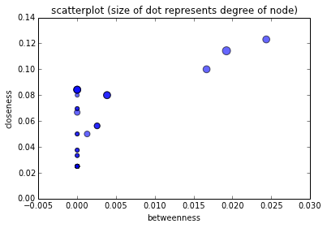

```python
plot.figure(1)
plot.scatter(DFCentrality.Betweenness, DFCentrality.Closeness,s=DFCentrality.Degree*1000, alpha=0.6)
plot.title("scatterplot (size of dot represents degree of node)")
plot.xlabel("betweenness")
plot.ylabel("closeness")
plot.show()
```

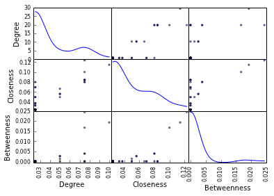

```python
scatter= pd.scatter_matrix(DFCentrality, diagonal='kde')
plot.show()
```

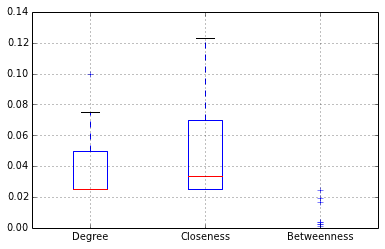

```python
plot.figure(4)
bp = DFCentrality.boxplot()
plot.show()
```

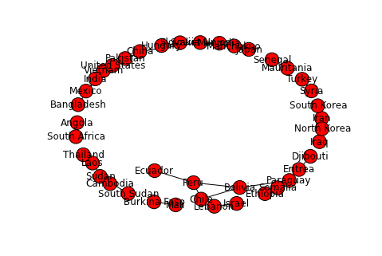

```python
plot.figure(5)
nx.draw(countriesGraph)
plot.show()
```

In the next tutorial I will do some deep cleaning to these data to export a file into R and Gephi.